# Notebook 10 – Solutions

## Getting Started

Before running this notebook, select “Session > Restart R and Clear Output” in the menu above to start a new R session. This will clear any old data sets and give us a blank slate to start with.

After starting a new session, run the following code chunk to load the libraries and data that we will be working with today.

I have set the options `include=FALSE` and `message=FALSE` to avoid cluttering the solutions with all the output from this code.

# Restructuring Data

## Motivation

In this notebook we introduce another set of methods for manipulating data sets. Table pivots, which are related by not identical to the spreadsheet concept of a *pivot table*, are a way or rearranging the values in a table without adding or lossing any additional information. This is achieved by either making the table longer (more rows, fewer columns) or wider (more columns, fewer rows).

What sort of situations would require going between two different formats with a different number of rows? As an example, consider a hypothetical experiment where we measure the heights of 100 plants every morning for two weeks. There are two different ways to store this data. We could have 100 rows, one for each plant, with variables `height_day1`, `height_day2`, and so on all the way through `height_day14`. Alternatively, we could have 1400 rows with just three columns: an id for the plant, a variable for the day, and a variable for height. Notice that both of these options capture the same information, but each privileges a particular kind of analysis.

In the wider table format, it is straightforward to compute the amount that each plot grew over the two weeks using a single mutate function. In the longer table format, it would be straightforward to filter by a specific plant id and draw a line plot showing the growth of a specific plant over the two week period. Both drawing a plot with the wider table or computing the growth with the longer table are possible, but require a surprising amount of work and code.

In this notebook we will introduce two new functions for alternating between wider and longer formats for a data set. These are principles that will be fundamental to several applications, particularly with text and temporal data sets.

For these notes, we will make use of the `food_prices` data set. As shown in our motivation example, pivoting is often a useful operation to apply when analyzing data collected over time. The data set is organized with year as the observation and each food type as a column.

```r
food_prices
```

```
## # A tibble: 146 x 14
##     year   tea sugar peanuts coffee cocoa wheat   rye  rice  corn barley  pork
##    <dbl> <dbl> <dbl>   <dbl>  <dbl> <dbl> <dbl> <dbl> <dbl> <dbl>  <dbl> <dbl>
##  1  1870  129.  151.    203.   88.1  78.8  88.1 103.   83.5 121.    103. 108.
##  2  1871  132.  167.    222.  109.   66.7 118.  105.   84.5  88.4   130.  68.5
##  3  1872  134.  162.    189.  140.   71.6 122.  102.   92.9  69.2   125.  58.6
##  4  1873  136.  154.    179.  173.   65.8 116.  106.   91.0  67.1   166.  62.9
##  5  1874  146.  153.    231.  187.   69.9 113.  126.   99.6 128.    174.  87.6
##  6  1875  149.  150.    197.  176.   69.4 110.  116.   85.8 127.    161. 113.
##  7  1876  150.  160.    172.  184.   80.7 114.  106.   95.3  91.2   132. 106.
##  8  1877  149.  189.    153.  198.   87.8 144.   97.0 108.   94.5   125.  84.0
##  9  1878  150.  165.    160.  169.   96.0 115.   91.6 114.   82.2   121.  60.3
## 10  1879  144.  158.    133.  149.  108.  118.  113.  110.   78.7   124.  61.1
## # … with 136 more rows, and 2 more variables: beef <dbl>, lamb <dbl>
```

This format makes it straightforward to compute the correlation between the prices of different kinds of food items. A longer format for the data set would, instead, have one row for each combination of year and food time.

In order to make this table longer, we will apply the `pivot_longer` function. This function requires knowing which current variables in the data set should be turned into values in the output data set. Often, it is easier to describe the set of values that will *not* be turned into values. Here, we indicate (with a minus sign) that the year value should remain as a variable in the output data set:

```r
food_prices %>%
  pivot_longer(-c(year))
```

```
## # A tibble: 1,898 x 3
##     year name    value
##    <dbl> <chr>   <dbl>
##  1  1870 tea     129.
##  2  1870 sugar   151.
##  3  1870 peanuts 203.
##  4  1870 coffee   88.1
##  5  1870 cocoa    78.8
##  6  1870 wheat    88.1
##  7  1870 rye     103.
##  8  1870 rice     83.5
##  9  1870 corn    121.
## 10  1870 barley  103.
## # … with 1,888 more rows
```

Already this looks close to what a long form of the food prices data set should look like. One improvement that we can make is to set better column names, which can be done by setting the options `names_to` and `values_to` in the function call:

```r
food_prices %>%
  pivot_longer(-c(year), names_to = "food", values_to = "price")
```

```
## # A tibble: 1,898 x 3
##     year food    price
##    <dbl> <chr>   <dbl>
##  1  1870 tea     129.
##  2  1870 sugar   151.
##  3  1870 peanuts 203.
##  4  1870 coffee   88.1
##  5  1870 cocoa    78.8
##  6  1870 wheat    88.1
##  7  1870 rye     103.
##  8  1870 rice     83.5
##  9  1870 corn    121.
## 10  1870 barley  103.
## # … with 1,888 more rows
```

The longer form of the data set makes it much easier to do some kinds of analysis. For example, we can draw a line chart of all of the food prices with a single graphics layer:

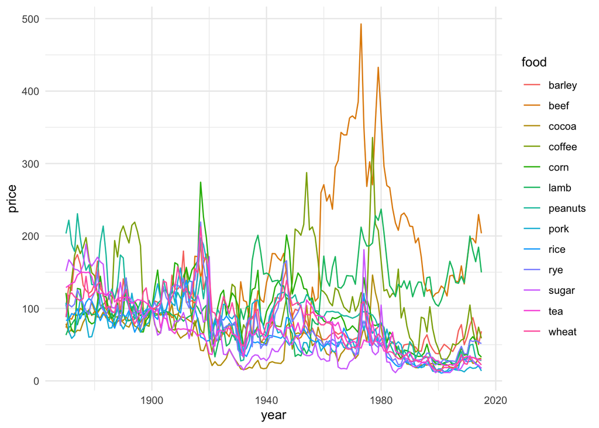

```r
food_prices %>%
  pivot_longer(-year, names_to = "food", values_to = "price") %>%
  ggplot() +
    geom_line(aes(x = year, y = price, color = food))
```

Drawing this plot with the original data set would require manually including a layer for each food type, selecting their colors, and building a manual legend. The alternative using the longer table is certainly the preferred approach.

## Pivot wider

To illustrate making a table wider, let’s create a new data set consisting of the long format of the food prices data set from just the years 1950 and 1975:

```r
food_prices_long <- food_prices %>%
  pivot_longer(-year, names_to = "food", values_to = "price") %>%
  filter(year %in% c(1950, 1975))
```

As described in our motivating example, it makes sense for some analyses to make each time point a column in a wider data set. To do this, we use the `pivot_wider` function. We need to indicate the current variable contains the values that will become new columns and the variable from which to take the values for the new column from. Here, the names will come from the `years` column (we want a new column for 1950 and another one for 1975) and the values will be filled in with prices.

```r
food_prices_long %>%
  pivot_wider(names_from = year, values_from = price)
```

```
## # A tibble: 13 x 3
##    food    `1950` `1975`
##    <chr>    <dbl>  <dbl>
##  1 tea       68.9   54.1
##  2 sugar     59.5  114.
##  3 peanuts  119.    95.6
##  4 coffee   210.   105.
##  5 cocoa     64.6   54.1
##  6 wheat    106.    74.8
##  7 rye       88.4   71.2
##  8 rice      62.7   74.2
##  9 corn     135.   113.
## 10 barley    98.8   91.3
## 11 pork      52.3   88.8
## 12 beef      62.4  268.
## 13 lamb      33.8  186.
```

One problem with the default output is that the column names now start with a number, which is not an allowed variable name in R. This makes it awkward to work with the data set; it is better to add a prefix to the names to make them valid. This can be done by setting the `names_prefix` option in the `pivot_wider` function.

```r
food_prices_long %>%
  pivot_wider(
    names_from = year, values_from = price, names_prefix = "year_"
  )
```

```
## # A tibble: 13 x 3
##    food    year_1950 year_1975
##    <chr>       <dbl>     <dbl>
##  1 tea          68.9      54.1
##  2 sugar        59.5     114.
##  3 peanuts     119.       95.6
##  4 coffee      210.      105.
##  5 cocoa        64.6      54.1
##  6 wheat       106.       74.8
##  7 rye          88.4      71.2
##  8 rice         62.7      74.2
##  9 corn        135.      113.
## 10 barley       98.8      91.3
## 11 pork         52.3      88.8
## 12 beef         62.4     268.
## 13 lamb         33.8     186.
```

This new form of the data set makes it straightforward to plot the price of each food type in 1975 as a function of its price in 1950.

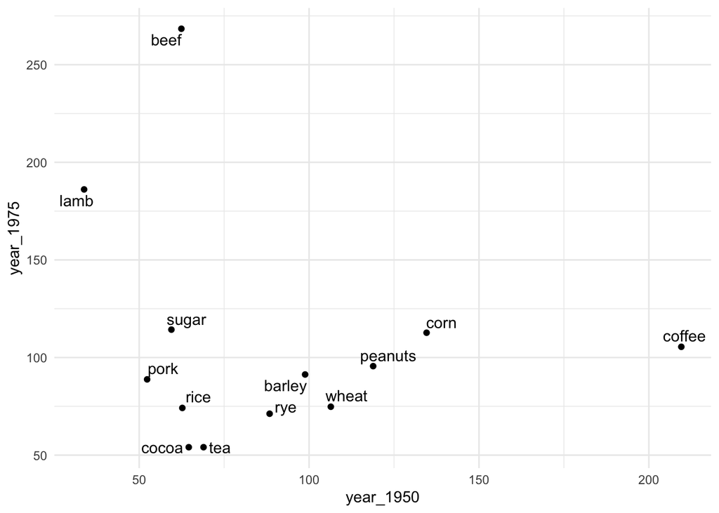

```r
food_prices_long %>%
  pivot_wider(names_from = year, values_from = price, names_prefix = "year_") %>%
  ggplot() +
    geom_point(aes(x = year_1950, y = year_1975)) +
    geom_text_repel(aes(x = year_1950, y = year_1975, label = food))
```

We can add some of the polishing touches mentioned in Notebook08 to make the plot even more readable.

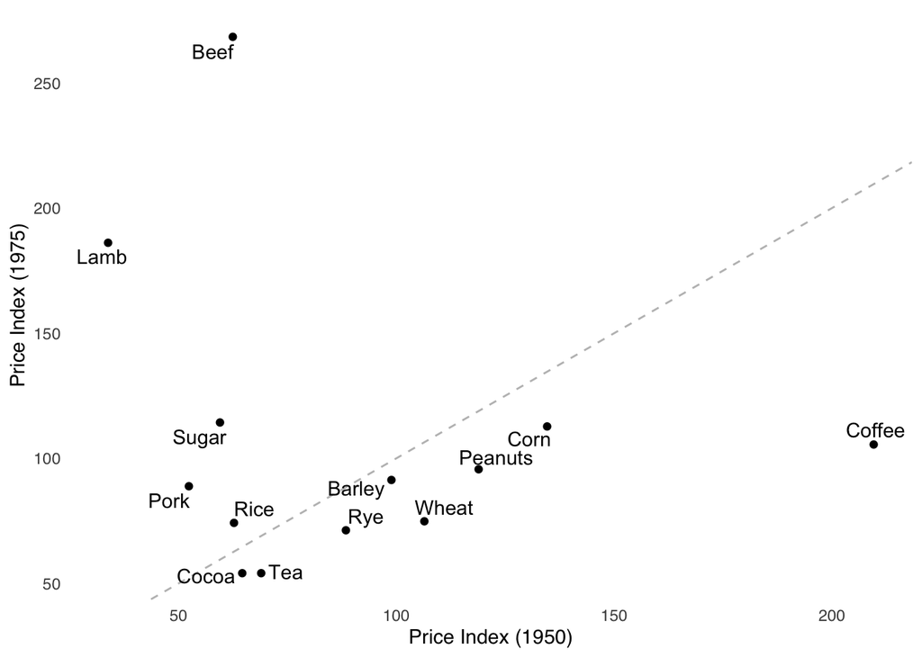

```r
food_prices_long %>%
  pivot_wider(names_from = year, values_from = price, names_prefix = "year_") %>%
  mutate(food = stri_trans_totitle(food)) %>%
  ggplot() +
    geom_abline(slope = 1, intercept = 0, linetype = "dashed", color = "grey") +
    geom_point(aes(x = year_1950, y = year_1975)) +
    geom_text_repel(aes(x = year_1950, y = year_1975, label = food)) +
    labs(x = "Price Index (1950)", y = "Price Index (1975)") +
    theme_sm()
```

In this new plot, can you see what products got much more expensive, much less expensive, and stayed about the same from 1950 to 1975?

## Patterns for table pivots

The syntax for making tables wider or longer is, on the surface, not much more complex than other table verbs that we have covered in this text. The biggest challenges with table pivots are identifying when they will simplify an analysis and not over-using them. The best way to avoid these issues is to store your data in the longest format that makes sense for your data. For example, in the motivating example about plant growth, it is better to store the data with 1400 rows and 3 columns.

Perhaps the biggest benefit of storing data in a longer format is to avoid the potentially complex chain of operations required to make the plot at the end of the previous section. The original data set is stored with years as rows and items as columns. Producing the plot requires thinking of years and columns and items as rows; this needed us to first pivot longer and then pivot wider. Keeping data in a longer format avoids the need for double pivots, while also making the different kinds of analysis (item and year, year by item, item by year) all reasonable accessible.

In my experience, some social scientists have a bad habit of storing data in extremely wide and unwieldy formats. It seems to be something that comes from the way that feels natural to organize survey and time-series data sets. For example, the U.S. Census Bureau produces data sets that often have hundreds of columns. Keep this in mind as you collect your own data, or work with external sources. Often an analysis that looks difficult at first will appear quite straightforward after pivoting your data set to a longer format.

# Practice

## Load data sets

In this notebook we will work with the U.S. city population data set.

```r
us <- read_csv(file.path("data", "us_city_population.csv"))
```

Please refer to notebook02a for more information about the data set.

## Widening Data: Cities as Observations

The `us` cities data set is a perfect candidate for widening. In its default form, there is one row for each unique combination of year and city. However, some plots and analyses are easier if we create a data set with either time or the cities.

Let’s start by creating a widened data set where each row is a city. The years will then be turned into columns. In the code below, create this data set using the `pivot_wider` function, with names coming from the years and values from the population. As we saw previously, use the names prefix “year_” to avoid column names staring with a number.

```r
us %>%
  pivot_wider(
    names_from = year, values_from = population, names_prefix = "year_"
   )
```

```
## # A tibble: 300 x 27
##    city  state    lon   lat year_1790 year_1800 year_1810 year_1820 year_1830
##    <chr> <chr>  <dbl> <dbl>     <dbl>     <dbl>     <dbl>     <dbl>     <dbl>
##  1 Anch… AK    -149.   61.2         0         0         0         0      0
##  2 Birm… AL     -86.8  33.5         0         0         0         0      0
##  3 Hunt… AL     -86.5  34.8         0         0         0         0      0
##  4 Mobi… AL     -88.1  30.7         0         0         0         0      3.19
##  5 Mont… AL     -86.3  32.3         0         0         0         0      0
##  6 Litt… AR     -92.4  34.7         0         0         0         0      0
##  7 Chan… AZ    -112.   33.3         0         0         0         0      0
##  8 Gilb… AZ    -112.   33.3         0         0         0         0      0
##  9 Glen… AZ    -112.   33.5         0         0         0         0      0
## 10 Mesa… AZ    -112.   33.4         0         0         0         0      0
## # … with 290 more rows, and 18 more variables: year_1840 <dbl>,
## #   year_1850 <dbl>, year_1860 <dbl>, year_1870 <dbl>, year_1880 <dbl>,
## #   year_1890 <dbl>, year_1900 <dbl>, year_1910 <dbl>, year_1920 <dbl>,
## #   year_1930 <dbl>, year_1940 <dbl>, year_1950 <dbl>, year_1960 <dbl>,
## #   year_1970 <dbl>, year_1980 <dbl>, year_1990 <dbl>, year_2000 <dbl>,
## #   year_2010 <dbl>
```

Below, take the data set created in the previous block and filter to include only cities with a population above 600 thousand in 2010. (Note: Do this after the pivot. It is much easier that way.) Then, plot the population of each city in 1950 on the x-axis and the population in 2010 on the y-axis with points and a text repel layer using the city names. Use logarithmic scales for the x- and y-axes.

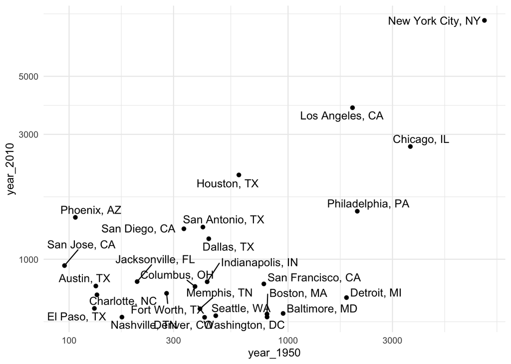

```r
us %>%
  pivot_wider(
    names_from = year, values_from = population, names_prefix = "year_"
   ) %>%
  filter(year_2010 > 600) %>%
  ggplot(aes(year_1950, year_2010)) +
    geom_text_repel(aes(label = city)) +
    geom_point() +
    scale_x_log10() +
    scale_y_log10()
```

Another graph that we can create using the wide version of the data set is an arrow plot showing the trend of each city over time. Below, piping the same data in as above, create a plot using the `geom_segment` layer with city of the y-axis and population on the x-axis. However, for this layer, you need to describe two additional aesthetics: `xend` and `yend`. Set `x` to the population in 1950 and `xend` to the population in 2010. The value for `yend` should be equal to the city name, the same as `y`.

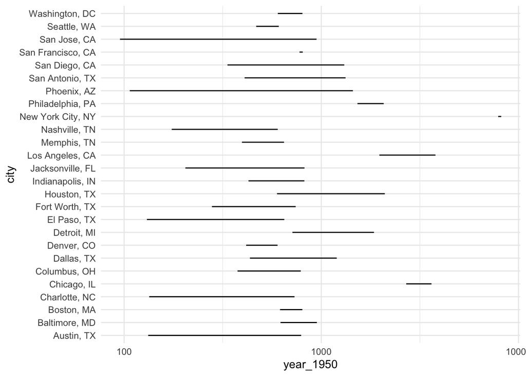

```r
us %>%
  pivot_wider(
    names_from = year, values_from = population, names_prefix = "year_"
   ) %>%
  filter(year_2010 > 600) %>%
  ggplot(aes(year_1950, city)) +
    geom_segment(aes(xend = year_2010, yend = city)) +
    scale_x_log10()
```

One issue with this plot is that it does not show which direction the population is changing (is it increasing or decreasing between 1950 and 2010?). We can fix this by adding an option to the `geom_segment` layer that turns the segment into an arrow. Namely:

`arrow = arrow(length = unit(0.02, "npc"))`

Below, modify the previous plot to include an arrow. Note that this line goes inside the `geom_segement` function, after the `aes` command. You may need to indent into a new line as is sometimes done in the notes to make the code easily readable. The `0.02` effects the size of the arrow and can be modified as you see fit.

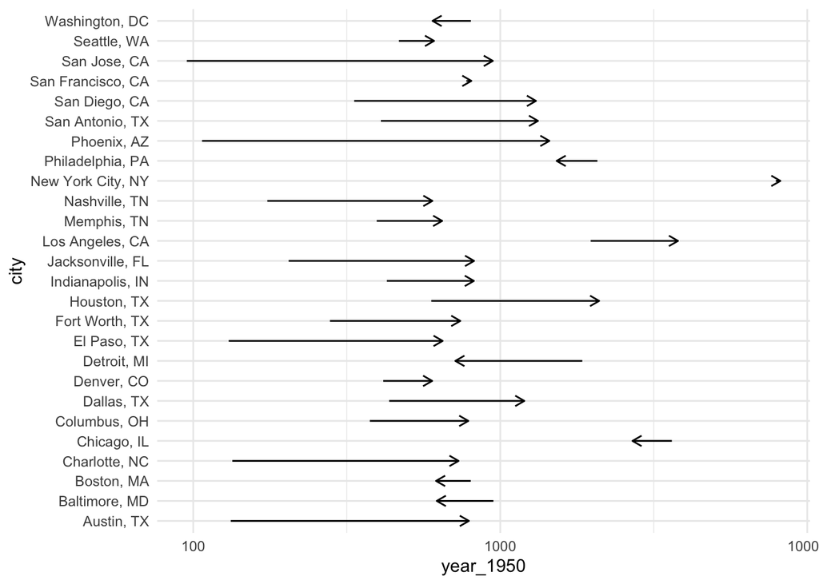

```r
us %>%
  pivot_wider(
    names_from = year, values_from = population, names_prefix = "year_"
   ) %>%
  filter(year_2010 > 600) %>%
  ggplot(aes(year_1950, city)) +
    geom_segment(
      aes(xend = year_2010, yend = city),
      arrow = arrow(length = unit(0.02, "npc"))
    ) +
    scale_x_log10()
```

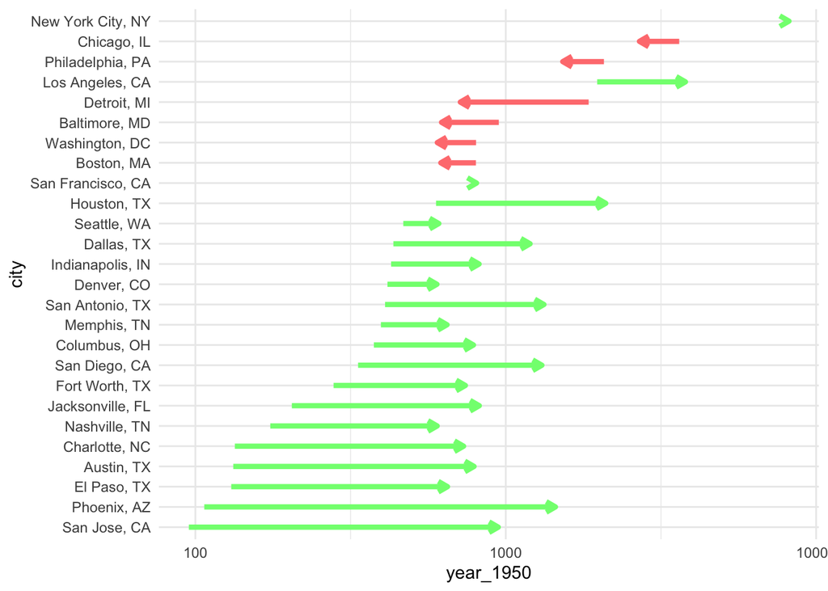

```r
us %>%
  pivot_wider(
    names_from = year, values_from = population, names_prefix = "year_"
   ) %>%
  filter(year_2010 > 600) %>%
  mutate(color = if_else(year_1950 > year_2010, "#FF7F7F", "#7FFF7F")) %>%
  arrange(year_1950) %>%
  mutate(city = fct_inorder(city)) %>%
  ggplot(aes(year_1950, city)) +
    geom_segment(
      aes(xend = year_2010, yend = city, color = color),
      size = 1.5,
      arrow = arrow(length = unit(0.02, "npc"))
    ) +
    scale_x_log10() +
    scale_color_identity()
```

## Widening Data: Years as Observations

Another possibility for pivoting the `us` data set is to have the observations be years and the variables be the cities In the code block below, try to `pivot_wider` using names from the city variable and values from the population. We do not need a variable prefix here.

```r
us %>%
  pivot_wider(names_from = city, values_from = population)
```

```
## # A tibble: 6,808 x 304
##    state  year    lon   lat `Anchorage, AK` `Birmingham, AL` `Huntsville, AL`
##    <chr> <dbl>  <dbl> <dbl>           <dbl>            <dbl>            <dbl>
##  1 AK     1790 -149.   61.2               0               NA               NA
##  2 AL     1790  -86.8  33.5              NA                0               NA
##  3 AL     1790  -86.5  34.8              NA               NA                0
##  4 AL     1790  -88.1  30.7              NA               NA               NA
##  5 AL     1790  -86.3  32.3              NA               NA               NA
##  6 AR     1790  -92.4  34.7              NA               NA               NA
##  7 AZ     1790 -112.   33.3              NA               NA               NA
##  8 AZ     1790 -112.   33.3              NA               NA               NA
##  9 AZ     1790 -112.   33.5              NA               NA               NA
## 10 AZ     1790 -112.   33.4              NA               NA               NA
## # … with 6,798 more rows, and 297 more variables: `Mobile, AL` <dbl>,
## #   `Montgomery, AL` <dbl>, `Little Rock, AR` <dbl>, `Chandler, AZ` <dbl>,
## #   `Gilbert, AZ` <dbl>, `Glendale, AZ` <dbl>, `Mesa, AZ` <dbl>, `Peoria,
## #   AZ` <dbl>, `Phoenix, AZ` <dbl>, `Scottsdale, AZ` <dbl>, `Tempe, AZ` <dbl>,
## #   `Tucson, AZ` <dbl>, `Anaheim, CA` <dbl>, `Antioch, CA` <dbl>, `Bakersfield,
## #   CA` <dbl>, `Berkeley, CA` <dbl>, `Burbank, CA` <dbl>, `Carson, CA` <dbl>,
## #   `Chula Vista, CA` <dbl>, `Compton, CA` <dbl>, `Concord, CA` <dbl>, `Corona,
## #   CA` <dbl>, `Costa Mesa, CA` <dbl>, `Daly City, CA` <dbl>, `Downey,
## #   CA` <dbl>, `El Cajon, CA` <dbl>, `El Monte, CA` <dbl>, `Escondido,
## #   CA` <dbl>, `Fairfield, CA` <dbl>, `Fontana, CA` <dbl>, `Fremont, CA` <dbl>,
## #   `Fresno, CA` <dbl>, `Fullerton, CA` <dbl>, `Garden Grove, CA` <dbl>,
## #   `Glendale, CA` <dbl>, `Hayward, CA` <dbl>, `Huntington Beach, CA` <dbl>,
## #   `Inglewood, CA` <dbl>, `Irvine, CA` <dbl>, `Lancaster, CA` <dbl>, `Long
## #   Beach, CA` <dbl>, `Los Angeles, CA` <dbl>, `Mission Viejo, CA` <dbl>,
## #   `Modesto, CA` <dbl>, `Moreno Valley, CA` <dbl>, `Norwalk, CA` <dbl>,
## #   `Oakland, CA` <dbl>, `Oceanside, CA` <dbl>, `Ontario, CA` <dbl>, `Orange,
## #   CA` <dbl>, `Oxnard, CA` <dbl>, `Palmdale, CA` <dbl>, `Pasadena, CA` <dbl>,
## #   `Pomona, CA` <dbl>, `Rancho Cucamonga, CA` <dbl>, `Rialto, CA` <dbl>,
## #   `Richmond, CA` <dbl>, `Riverside, CA` <dbl>, `Sacramento, CA` <dbl>,
## #   `Salinas, CA` <dbl>, `San Bernardino, CA` <dbl>, `San Diego, CA` <dbl>,
## #   `San Francisco, CA` <dbl>, `San Jose, CA` <dbl>, `San Mateo, CA` <dbl>,
## #   `Santa Ana, CA` <dbl>, `Santa Barbara, CA` <dbl>, `Santa Clara, CA` <dbl>,
## #   `Santa Clarita, CA` <dbl>, `Santa Rosa, CA` <dbl>, `Simi Valley, CA` <dbl>,
## #   `South Gate, CA` <dbl>, `Stockton, CA` <dbl>, `Sunnyvale, CA` <dbl>,
## #   `Thousand Oaks, CA` <dbl>, `Torrance, CA` <dbl>, `Vacaville, CA` <dbl>,
## #   `Vallejo, CA` <dbl>, `Ventura, CA` <dbl>, `Visalia, CA` <dbl>, `Vista,
## #   CA` <dbl>, `West Covina, CA` <dbl>, `Westminster, CA` <dbl>, `Arvada,
## #   CO` <dbl>, `Aurora, CO` <dbl>, `Boulder, CO` <dbl>, `Colorado Springs,
## #   CO` <dbl>, `Denver, CO` <dbl>, `Fort Collins, CO` <dbl>, `Lakewood,
## #   CO` <dbl>, `Pueblo, CO` <dbl>, `Westminster, CO` <dbl>, `Bridgeport,
## #   CT` <dbl>, `Hartford, CT` <dbl>, `New Haven, CT` <dbl>, `Stamford,
## #   CT` <dbl>, `Waterbury, CT` <dbl>, `Washington, DC` <dbl>, `Cape Coral,
## #   FL` <dbl>, `Clearwater, FL` <dbl>, …
```

You should see that there is a problem. The issue is that there are several other variables tied to each specific city (lon, lat, and state) that make the output data set have many missing values and far too many rows. Modify the code above by first using the `select` function to grab only the three variables `city`, `year`, and `population`.

```r
us %>%
  select(city, year, population) %>%
  pivot_wider(names_from = city, values_from = population)
```

```
## # A tibble: 23 x 301
##     year `Anchorage, AK` `Birmingham, AL` `Huntsville, AL` `Mobile, AL`
##    <dbl>           <dbl>            <dbl>            <dbl>        <dbl>
##  1  1790               0             0                0            0
##  2  1800               0             0                0            0
##  3  1810               0             0                0            0
##  4  1820               0             0                0            0
##  5  1830               0             0                0            3.19
##  6  1840               0             0                0           12.7
##  7  1850               0             0                2.86        20.5
##  8  1860               0             0                3.63        29.3
##  9  1870               0             0                4.91        32.0
## 10  1880               0             3.09             4.98        29.1
## # … with 13 more rows, and 296 more variables: `Montgomery, AL` <dbl>, `Little
## #   Rock, AR` <dbl>, `Chandler, AZ` <dbl>, `Gilbert, AZ` <dbl>, `Glendale,
## #   AZ` <dbl>, `Mesa, AZ` <dbl>, `Peoria, AZ` <dbl>, `Phoenix, AZ` <dbl>,
## #   `Scottsdale, AZ` <dbl>, `Tempe, AZ` <dbl>, `Tucson, AZ` <dbl>, `Anaheim,
## #   CA` <dbl>, `Antioch, CA` <dbl>, `Bakersfield, CA` <dbl>, `Berkeley,
## #   CA` <dbl>, `Burbank, CA` <dbl>, `Carson, CA` <dbl>, `Chula Vista,
## #   CA` <dbl>, `Compton, CA` <dbl>, `Concord, CA` <dbl>, `Corona, CA` <dbl>,
## #   `Costa Mesa, CA` <dbl>, `Daly City, CA` <dbl>, `Downey, CA` <dbl>, `El
## #   Cajon, CA` <dbl>, `El Monte, CA` <dbl>, `Escondido, CA` <dbl>, `Fairfield,
## #   CA` <dbl>, `Fontana, CA` <dbl>, `Fremont, CA` <dbl>, `Fresno, CA` <dbl>,
## #   `Fullerton, CA` <dbl>, `Garden Grove, CA` <dbl>, `Glendale, CA` <dbl>,
## #   `Hayward, CA` <dbl>, `Huntington Beach, CA` <dbl>, `Inglewood, CA` <dbl>,
## #   `Irvine, CA` <dbl>, `Lancaster, CA` <dbl>, `Long Beach, CA` <dbl>, `Los
## #   Angeles, CA` <dbl>, `Mission Viejo, CA` <dbl>, `Modesto, CA` <dbl>, `Moreno
## #   Valley, CA` <dbl>, `Norwalk, CA` <dbl>, `Oakland, CA` <dbl>, `Oceanside,
## #   CA` <dbl>, `Ontario, CA` <dbl>, `Orange, CA` <dbl>, `Oxnard, CA` <dbl>,
## #   `Palmdale, CA` <dbl>, `Pasadena, CA` <dbl>, `Pomona, CA` <dbl>, `Rancho
## #   Cucamonga, CA` <dbl>, `Rialto, CA` <dbl>, `Richmond, CA` <dbl>, `Riverside,
## #   CA` <dbl>, `Sacramento, CA` <dbl>, `Salinas, CA` <dbl>, `San Bernardino,
## #   CA` <dbl>, `San Diego, CA` <dbl>, `San Francisco, CA` <dbl>, `San Jose,
## #   CA` <dbl>, `San Mateo, CA` <dbl>, `Santa Ana, CA` <dbl>, `Santa Barbara,
## #   CA` <dbl>, `Santa Clara, CA` <dbl>, `Santa Clarita, CA` <dbl>, `Santa Rosa,
## #   CA` <dbl>, `Simi Valley, CA` <dbl>, `South Gate, CA` <dbl>, `Stockton,
## #   CA` <dbl>, `Sunnyvale, CA` <dbl>, `Thousand Oaks, CA` <dbl>, `Torrance,
## #   CA` <dbl>, `Vacaville, CA` <dbl>, `Vallejo, CA` <dbl>, `Ventura, CA` <dbl>,
## #   `Visalia, CA` <dbl>, `Vista, CA` <dbl>, `West Covina, CA` <dbl>,
## #   `Westminster, CA` <dbl>, `Arvada, CO` <dbl>, `Aurora, CO` <dbl>, `Boulder,
## #   CO` <dbl>, `Colorado Springs, CO` <dbl>, `Denver, CO` <dbl>, `Fort Collins,
## #   CO` <dbl>, `Lakewood, CO` <dbl>, `Pueblo, CO` <dbl>, `Westminster,
## #   CO` <dbl>, `Bridgeport, CT` <dbl>, `Hartford, CT` <dbl>, `New Haven,
## #   CT` <dbl>, `Stamford, CT` <dbl>, `Waterbury, CT` <dbl>, `Washington,
## #   DC` <dbl>, `Cape Coral, FL` <dbl>, `Clearwater, FL` <dbl>, `Coral Springs,
## #   FL` <dbl>, …
```

You should now have a data set with 23 rows (one for each year) and 301 columns (a year column and 300 cities). The shape of this data set is fine, but the column names are difficult to work with because they contain spaces and commas. We can fix this by changing the city names using some string processing. Run the following code to create a new version of the us cities data called `us_cities`:

```r
us_cities <- us %>%
  mutate(city = stri_trans_tolower(city)) %>%
  mutate(city = stri_replace_all(city, "", regex = "[^a-z ]")) %>%
  mutate(city = stri_replace_all(city, "_", fixed = " "))
```

Run the answer to your last question with the new dataset `us_cities` and verify that the names are now “proper” R variable names:

```r
us_cities %>%
  select(city, year, population) %>%
  pivot_wider(names_from = city, values_from = population)
```

```
## # A tibble: 23 x 301
##     year anchorage_ak birmingham_al huntsville_al mobile_al montgomery_al
##    <dbl>        <dbl>         <dbl>         <dbl>     <dbl>         <dbl>
##  1  1790            0          0             0         0             0
##  2  1800            0          0             0         0             0
##  3  1810            0          0             0         0             0
##  4  1820            0          0             0         0             0
##  5  1830            0          0             0         3.19          0
##  6  1840            0          0             0        12.7           2.2
##  7  1850            0          0             2.86     20.5           8.73
##  8  1860            0          0             3.63     29.3           8.84
##  9  1870            0          0             4.91     32.0          10.6
## 10  1880            0          3.09          4.98     29.1          16.7
## # … with 13 more rows, and 295 more variables: little_rock_ar <dbl>,
## #   chandler_az <dbl>, gilbert_az <dbl>, glendale_az <dbl>, mesa_az <dbl>,
## #   peoria_az <dbl>, phoenix_az <dbl>, scottsdale_az <dbl>, tempe_az <dbl>,
## #   tucson_az <dbl>, anaheim_ca <dbl>, antioch_ca <dbl>, bakersfield_ca <dbl>,
## #   berkeley_ca <dbl>, burbank_ca <dbl>, carson_ca <dbl>, chula_vista_ca <dbl>,
## #   compton_ca <dbl>, concord_ca <dbl>, corona_ca <dbl>, costa_mesa_ca <dbl>,
## #   daly_city_ca <dbl>, downey_ca <dbl>, el_cajon_ca <dbl>, el_monte_ca <dbl>,
## #   escondido_ca <dbl>, fairfield_ca <dbl>, fontana_ca <dbl>, fremont_ca <dbl>,
## #   fresno_ca <dbl>, fullerton_ca <dbl>, garden_grove_ca <dbl>,
## #   glendale_ca <dbl>, hayward_ca <dbl>, huntington_beach_ca <dbl>,
## #   inglewood_ca <dbl>, irvine_ca <dbl>, lancaster_ca <dbl>,
## #   long_beach_ca <dbl>, los_angeles_ca <dbl>, mission_viejo_ca <dbl>,
## #   modesto_ca <dbl>, moreno_valley_ca <dbl>, norwalk_ca <dbl>,
## #   oakland_ca <dbl>, oceanside_ca <dbl>, ontario_ca <dbl>, orange_ca <dbl>,
## #   oxnard_ca <dbl>, palmdale_ca <dbl>, pasadena_ca <dbl>, pomona_ca <dbl>,
## #   rancho_cucamonga_ca <dbl>, rialto_ca <dbl>, richmond_ca <dbl>,
## #   riverside_ca <dbl>, sacramento_ca <dbl>, salinas_ca <dbl>,
## #   san_bernardino_ca <dbl>, san_diego_ca <dbl>, san_francisco_ca <dbl>,
## #   san_jose_ca <dbl>, san_mateo_ca <dbl>, santa_ana_ca <dbl>,
## #   santa_barbara_ca <dbl>, santa_clara_ca <dbl>, santa_clarita_ca <dbl>,
## #   santa_rosa_ca <dbl>, simi_valley_ca <dbl>, south_gate_ca <dbl>,
## #   stockton_ca <dbl>, sunnyvale_ca <dbl>, thousand_oaks_ca <dbl>,
## #   torrance_ca <dbl>, vacaville_ca <dbl>, vallejo_ca <dbl>, ventura_ca <dbl>,
## #   visalia_ca <dbl>, vista_ca <dbl>, west_covina_ca <dbl>,
## #   westminster_ca <dbl>, arvada_co <dbl>, aurora_co <dbl>, boulder_co <dbl>,
## #   colorado_springs_co <dbl>, denver_co <dbl>, fort_collins_co <dbl>,
## #   lakewood_co <dbl>, pueblo_co <dbl>, westminster_co <dbl>,
## #   bridgeport_ct <dbl>, hartford_ct <dbl>, new_haven_ct <dbl>,
## #   stamford_ct <dbl>, waterbury_ct <dbl>, washington_dc <dbl>,
## #   cape_coral_fl <dbl>, clearwater_fl <dbl>, coral_springs_fl <dbl>,
## #   fort_lauderdale_fl <dbl>, …
```

Starting with the code above, create a plot with one city (of your choosing) on the x-axis, another city (of your choosing) on the y-axis using a text layer where the label is given by the year. Use a `geom_path` layer and an text repel layer labeled by year. This should allow you to see how the population of the two cities change together over time.

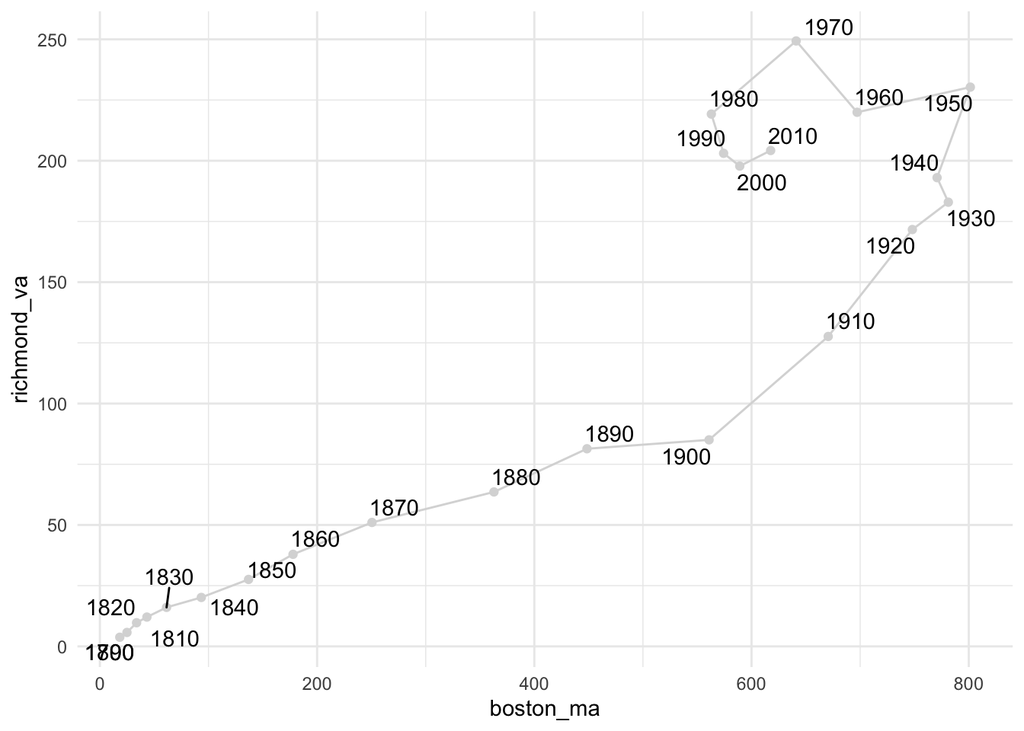

```r
us_cities %>%
  select(city, year, population) %>%
  pivot_wider(names_from = city, values_from = population) %>%
  ggplot(aes(boston_ma, richmond_va)) +
    geom_point(color = "grey85") +
    geom_path(color = "grey85") +
    geom_text_repel(aes(label = year))
```

Note that the `geom_path` geometry is different than the `geom_line` geometry. The latter always connects dots from the smallest x-value to the largest x-value, whereas the path geometry connects the dots in the order they appear in the data.

## Closing Thoughts

The `us` data set is a nice example of how keeping data in a long format makes it relatively easy to work with the data as-is or in various wider formats. In this example, the cities as observations seems to allow more interesting plots. However, the second format will be more useful for building the kinds of time series models we introduce in the applications with temporal data sets.